# Test_a_Perceptual_Phenomenon

#### 1) What is our independent variable? What is our dependent variable?

The type of words, Congruent or Incongruent, is independent variable, the time used to recognize the words is dependent variable

#### 2) What is an appropriate set of hypotheses for this task? What kind of statistical test do you expect to perform? Justify your choices.

The null hypotheses is **Congruent and Incongruent have the same population mean**

$H_0: \mu_{Congruent} = \mu_{Incongruent}$

The alternative hypotheses is **Congruent and Incongruent do not have the same population mean**

$H_a: \mu_{Congruent} \neq \mu_{Incongruent}$

#### 3) Report some descriptive statistics regarding this dataset. Include at least one measure of central tendency and at least one measure of variability

For the data above, we could find the the mean, mode, median and std for Congruent and Incongruent

```python
import csv
import numpy as np
from scipy import stats
%pylab inline
import matplotlib.pyplot as plt


def describe(name, list):

    mean = np.mean(list)
    mode = stats.mode(list)
    median = np.median(list)
    std = np.std(list,ddof=1)
    print 'mean for {} is {:.2f}'.format(name, mean)
    print 'mode for {} is {}'.format(name, mode)
    print 'median for {} is {:.2f}'.format(name, median)
    print 'std for {} is {:.2f}'.format(name, std)

#with open('stroopdata.csv','rb') as csvfile:
#    r = csv.DictReader(csvfile)

def read_csv(filename):
    with open(filename, 'rb') as f:
        reader = csv.DictReader(f)
        return list(reader)

r = read_csv('stroopdata.csv')

Congruent=[]
Incongruent=[]

for row in r:
    Congruent.append(float(row['Congruent']))
    Incongruent.append(float(row['Incongruent']))

describe("Congruent",Congruent)
print ''
describe("Incongruent",Incongruent)
```

```
mean for Congruent is 14.05
mode for Congruent is ModeResult(mode=array([ 8.63]), count=array([1]))
median for Congruent is 14.36
std for Congruent is 3.56

mean for Incongruent is 22.02
mode for Incongruent is ModeResult(mode=array([ 15.687]), count=array([1]))
median for Incongruent is 21.02
std for Incongruent is 4.80
```

#### 4) Provide one or two visualizations that show the distribution of the sample data. Write one or two sentences noting what you observe about the plot or plots.

The following plot show the distribution of the sample data.

The peak for the Congruent and Incongruent data are different. And Incongruent data is more wide than the Congruent data.

```
Number of Samples is 24
```

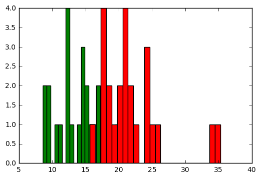

```python
#%matplotlib inline

print ''
print "Number of Samples is {}".format(len(Congruent))

plt.hist(Congruent,len(Congruent), facecolor='green');
plt.hist(Incongruent,len(Incongruent), facecolor='red');
plt.show();
```

#### 5) Now, perform the statistical test and report your results. What is your confidence level and your critical statistic value? Do you reject the null hypothesis or fail to reject it? Come to a conclusion in terms of the experiment task. Did the results match up with your expectations?

$H_0: \mu_{Congruent} = \mu_{Incongruent}$

$H_a: \mu_{Congruent} \neq \mu_{Incongruent}$

```python
#The Mean of difference is :
diff = np.array(Incongruent) - np.array(Congruent)
diff_mean= np.mean(diff)
print diff_mean
```

```
7.96479166667
```

```python
#The Standard Deviation of Mean is :
diff_std = np.std(diff,ddof=1)
print diff_std
```

```
4.86482691036
```

```python
#The Standard Error of Mean is :
diff_SE = diff_std / np.sqrt(len(Congruent))
print diff_SE
```

```
0.993028634778
```

```python
#The t-statistic is  :
t_stat = diff_mean / diff_SE
print t_stat
```

```
8.02070694411
```

#### 6) Optional: What do you think is responsible for the effects observed? Can you think of an alternative or similar task that would result in a similar effect? Some research about the problem will be helpful for thinking about these two questions!

The effects should caused by the different response time between color information and word information. We could test like "shape" and “word” with congruent and incongruent samples. It could test the similar effect.